# Natural Language Processing - Sentiment Analysis

Ali Zaidi

2017/06/05

## Text Classification

Let’s take a look at using `MML` to estimate a model that would be very hard to do with `RevoScaleR`.

In particular, there are virtually no functionality in `RevoScaleR` for handling large text data. We will use `MML` to transform text data into useful features that we can use in a logistic regression learner. In order to deal with the high cardinality of text data, we will use the penalized regression models in `MML`.

### IMDB Data

Our data is taken from the paper **Learning Word Vectors for Sentiment Analysis** written in 2011 by Andrew L. Maas, Raymond E. Daly, Peter T. Pham, Dan Huang, Andrew Y. Ng, and Christopher Potts. The paper and data are available here: http://ai.stanford.edu/~amaas/data/sentiment/. I’ve already downloaded and converted the data into an XDF. Please see the `1-ingest-data.R` script if you are interested in the ingestion process.

```r
cc <- rxSparkConnect()
```

```
No Spark applications can be reused. It may take 1 to 2 minutes to launch a new Spark application.
```

```r
train_xdf <- RxXdfData("/imdbdata/train/",
                       fileSystem = RxHdfsFileSystem())
test_xdf <- RxXdfData("/imdbdata/test",
                      fileSystem = RxHdfsFileSystem())
```

### Feature Transformers

MicrosoftML has a set of functions for feature engineering. In this example, let’s take a look at creating sparse word vectors.

We’ll use the `featurizeText` function to convert our text data into numeric columns. In particular, we’ll ask for new columns with tri-grams after removing stopwords, punctuations, and numbers.

We can do this transform directly in our modeling call, and in particular, we’ll train logistic regression models and a fast gradient boosted tree model:

```r
system.time(logit_model <- rxLogisticRegression(sentiment ~ reviewTran,
                                                data = train_xdf,
                                                l1Weight = 0.05,
                                                l2Weight = 0.05,
                                                mlTransforms = list(featurizeText(vars = c(reviewTran = "review"),
                                                                                  language = "English",
                                                                                  stopwordsRemover = stopwordsDefault(),
                                                                                  wordFeatureExtractor = ngramCount(3),
                                                                                  keepNumbers = FALSE,
                                                                                  keepPunctuations = FALSE)))
)
```

```
Elapsed time: 00:01:12.0505449
   user  system elapsed
  3.752   3.908 241.737
```

```r
system.time(fast_trees <- rxFastTrees(sentiment ~ reviewTran,
                                       data = train_xdf,
                                       mlTransforms = list(featurizeText(vars = c(reviewTran = "review"),
                                                                         language = "English",
                                                                         stopwordsRemover = stopwordsDefault(),
                                                                         wordFeatureExtractor = ngramCount(3),
                                                                         keepNumbers = FALSE,
                                                                         keepPunctuations = FALSE)))
)
```

```
   user  system elapsed
  3.036   3.236 116.329
```

Now that we have our trained model, we can do some visualizations. For example, for the elastic net, we can visualize the coefficients.

[figure not shown]

```r
library(dplyr)
logit_cof <- coefficients(logit_model)
coefs <- data.frame(coef = logit_cof, word = names(logit_cof))
coefs <- tbl_df(coefs)
coefs <- coefs %>%
  filter(word != "(Bias)") %>%
  mutate(abs_value = abs(coef),
         sentiment = ifelse(coef > 0, "Positive", "Negative"),
         score = round(abs_value, 0)) %>%
  arrange(desc(abs_value)) %>% slice(1:100)
library(ggplot2)
library(ggrepel)
coefs %>%
  ggplot +
    aes(x = 1, y = 1, colour = sentiment, size = score, label = word) +
    geom_text_repel(segment.size = 0, force = 10) +
    scale_size(range = c(2, 15), guide = FALSE) +
    scale_y_continuous(breaks = NULL) +
    scale_x_continuous(breaks = NULL) +
    labs(x = '', y = '') +
    theme_classic() +
    facet_wrap(~sentiment)
```

Let’s try and makea more interactive visual. We’ll use `purrr` again to map our coefficients to the beautiful d3wordcloud package

```r
library(magrittr)
library(d3wordcloud)
coefs %>%
  split(.$sentiment) %>%
  purrr::map( ~ d3wordcloud(.$word, .$score, tooltip = TRUE)) -> d3_graphs
d3_graphs[[1]]
```

[interactive chart not shown]

```r
d3_graphs[[2]]
```

[interactive chart not shown]

### Testing the Logit Model

```r
names(pred_logit)[ncol(pred_logit)]
```

```
[1] "Probability.1"
```

### Testing the Fast Trees Model

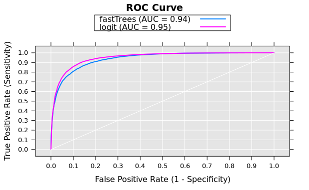

## Neural Networks

Let’s try to estimate another binary classifier from this dataset, but with a Neural Network architecture rather than a logistic regression model.

```r
nn_sentiment <- rxNeuralNet(sentiment ~ reviewTran,
                            data = train_xdf,
                            type = "binary",
                            mlTransforms = list(featurizeText(vars = c(reviewTran = "review"),
                                                         language = "English",
                                                         stopwordsRemover = stopwordsDefault(),
                                                         keepPunctuations = FALSE)),
                          # acceleration = "gpu",
                          miniBatchSize = 4)
```

[output not shown]

[output cut: 95 more lines]

```
Iter:91/100, MeanErr=0.270917(-0.74%), 50922.90M WeightUpdates/sec
Iter:92/100, MeanErr=0.269519(-0.52%), 51721.80M WeightUpdates/sec
Iter:93/100, MeanErr=0.267711(-0.67%), 50527.39M WeightUpdates/sec
Iter:94/100, MeanErr=0.266137(-0.59%), 50995.86M WeightUpdates/sec
Iter:95/100, MeanErr=0.264770(-0.51%), 50198.90M WeightUpdates/sec
Iter:96/100, MeanErr=0.262845(-0.73%), 50828.91M WeightUpdates/sec
Iter:97/100, MeanErr=0.261513(-0.51%), 50646.78M WeightUpdates/sec
Iter:98/100, MeanErr=0.259934(-0.60%), 50948.97M WeightUpdates/sec
Iter:99/100, MeanErr=0.258394(-0.59%), 51057.36M WeightUpdates/sec
Iter:100/100, MeanErr=0.257150(-0.48%), 50745.84M WeightUpdates/sec
Done!
Estimated Post-training MeanError = 0.256146
___________________________________________________________________
Not training a calibrator because it is not needed.
Elapsed time: 00:06:22.9861989
```

### Scoring the Neural Net

We can similary score our results from the neural network model

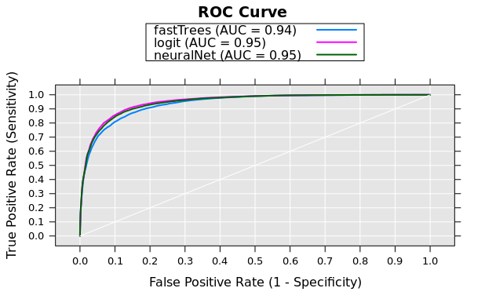